# Report Automation

Germania Automated Reporting Service

garservice.github.io

# About Us

[figure not shown]

Backed freshly from the founder, [Cevi Herdian](https://itsmecevi.github.io/), the company will bring automation to your reporting

projects. Our tools powered by Microsoft and Tableau open source software and newest methods, it includes:

1. Microsoft Excel
2. Microsoft Power Query
3. Microsoft Power Pivot
4. Microsoft Power View
5. Microsoft Power Maps
6. Microsoft Power Business Intelligence
7. Tableau Business Intelligence & Analytics
8. DAX (Data Analysis Expressions)
9. Data Modelling (Star Schema, Relational, etc)
10. KPI (Key Performances Indicators)
11. Data Cleaning

[figure not shown]

# A New Era

**No more waiting. No more grinding.**

Until recently, turning data into actionable insight was overwhelmingly bottlenecked on two different activities:

- Waiting on a Business Intelligence (BI) team to finish a project - expensive, slow, and frustrating AND/OR
- Grinding on a collection of spreadsheets - repetitive, labor intensive, and chaotic

Today, however, we have been given the most precious of gifts: a way to escape the limits imposed by prior technology. To unshackle our thinking. To put the human beings back in charge. To return our focus to the original reason for the entire “data endeavor” - to improve.

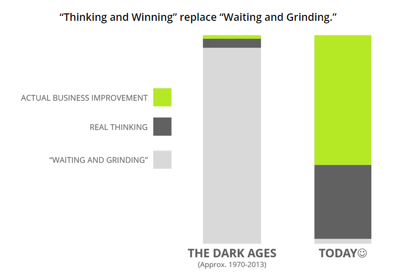

# Automated Reporting

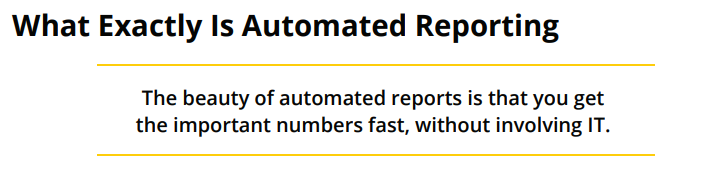

[figure not shown]

**6 Reasons to start Report Automation**

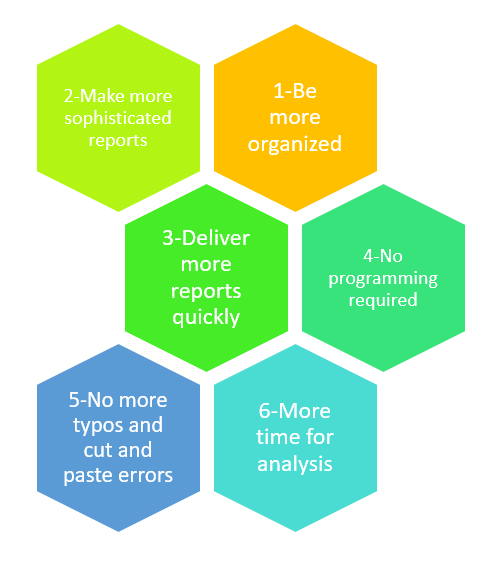

**Cut off your time!**

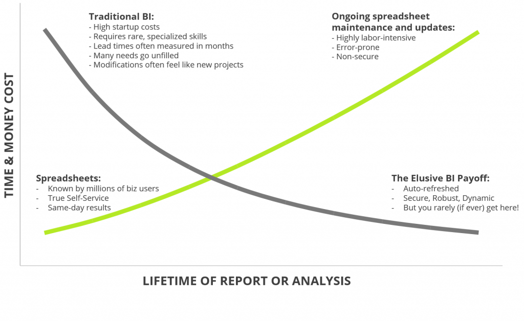

**Cut off your cost!**

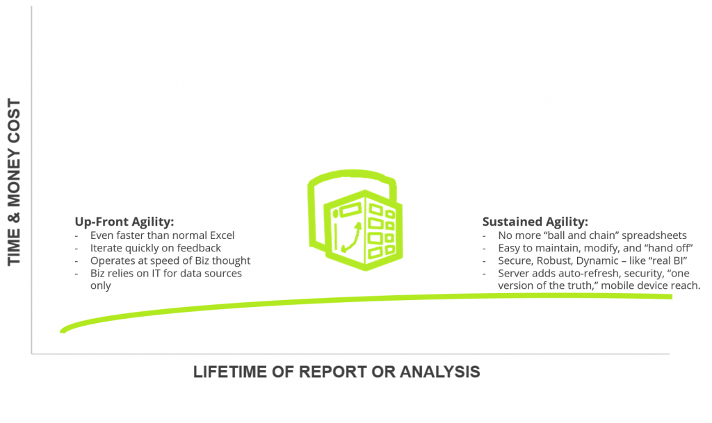

**What you get from Germania Automated Reporting service:**

1. One click open source reporting software without programming
2. Technical Documentation
3. Unlimited customer service and maintenance
4. Essential Training (optional), it includes:
- Microsoft Excel Modul
- Microsoft Power Query Modul
- Microsoft Power Pivot Modul
- Microsoft Power View Modul
- Microsoft Power Maps Modul
- Microsoft Power Business Intelligence Modul
- Tableau Business Intelligence & Analytics Modul
- DAX (Data Analysis Expressions) Modul
- Data Modelling (Star Schema, Relational, etc) Modul
- KPI (Key Performances Indicators) Modul
- Data Cleaning Modul

# Tools & Methods

**Microsoft Excel**

Microsoft Excel is a software program produced by Microsoft that allows users to organize, format and calculate data with formulas using a spreadsheet system. This software is part of the Microsoft Office suite and is compatible with other applications in the Office suite.

[figure not shown]

**Microsoft Power Query**

Power Query is a data connection technology that enables you to discover, connect, combine, and refine data sources to meet your analysis needs. Features in Power Query are available in Excel and Power BI Desktop.

Power Query enhances self-service business intelligence (BI) for Excel and Power BI with an intuitive and consistent experience for discovering, combining, and refining data across a wide variety of sources including relational, structured and semi-structured, OData, Web, Hadoop, and more.

[figure not shown]

**Microsoft Power Pivot**

Power Pivot is an Microsoft add-in you can use to perform powerful data analysis and create sophisticated data models. With Power Pivot, you can mash up large volumes of data from various sources, perform information analysis rapidly, and share insights easily.

Power Pivot is basically a SQL Server Analysis Services engine made available using an in-memory process. It is commonly referred to as an Internal Data Model. It can handle large volumes of data (millions of rows) from various sources and all of this within a single file.

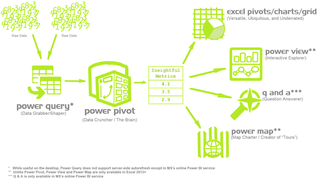

**Microsoft Power View**

Power View is a data visualization technology that lets you create interactive charts, graphs, maps, and other visuals that bring your data to life. Power View is available in Excel, in SharePoint, SQL Server, and Power BI.

[figure not shown]

**Microsoft Power Maps**

Microsoft Power Map is a three-dimensional (3-D) data visualization tool that lets you look at information in new ways. A power map lets you discover insights you might not see in traditional two-dimensional (2-D) tables and charts.

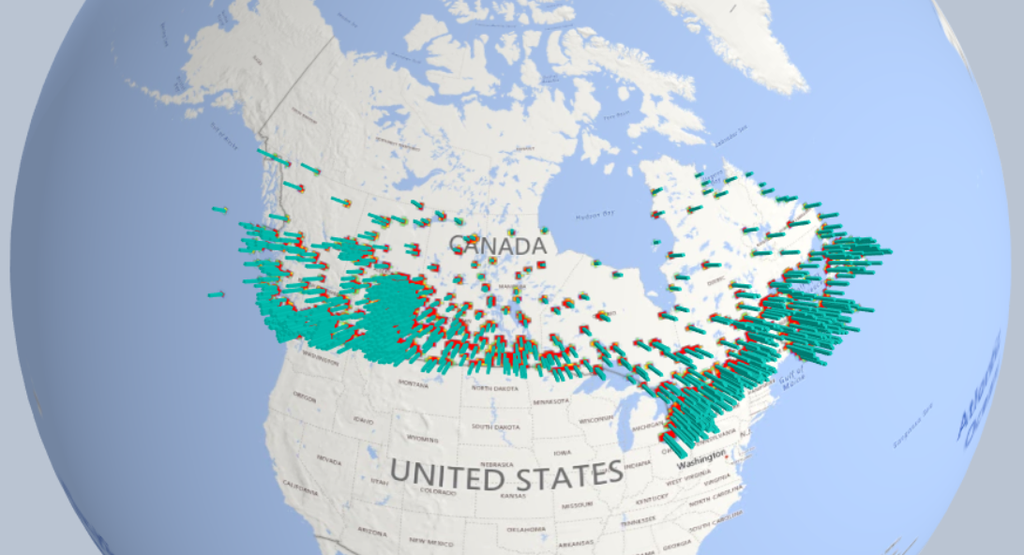

**Microsoft Power BI**

Power BI is a business analytics service that delivers insights to enable fast, informed decisions.

- Transform data into stunning visuals and share them with colleagues on any device.
- Visually explore and analyze data-on-premises and in the cloud-all in one view.
- Collaborate on and share customized dashboards and interactive reports.
- Scale across your organization with built-in governance and security.

[figure not shown]

**Tableau BI**

From connection through collaboration, Tableau is the most powerful, secure, and flexible end-to-end analytics platform for your data. Elevate people with the power of data. Designed for the individual, but scaled for the enterprise, Tableau is the only business intelligence platform that turns your data into insights that drive action.

[figure not shown]

**DAX (Data Analysis Expressions)**

DAX is a collection of functions, operators, and constants that can be used in a formula, or expression, to calculate and return one or more values. Stated more simply, DAX helps you create new information from data already in your model.

[figure not shown]

**Data Modelling**

A data model refers to the logical inter-relationships and data flow between different data elements involved in the information world. It also documents the way data is stored and retrieved. This data model is a conceptual representation of

- Data objects
- The associations between different data objects
- The rules

[figure not shown]

**KPI (Key Performances Indicators)**

A Key Performance Indicator is a measurable value that demonstrates how effectively a company is achieving key business objectives. Organizations use KPIs at multiple levels to evaluate their success at reaching targets. High-level KPIs may focus on the overall performance of the business, while low-level KPIs may focus on processes in departments such as sales, marketing, HR, support and others.

[figure not shown]

**Data Cleaning**

Data cleaning is the process of preparing data for analysis by removing or modifying data that is incorrect, incomplete, irrelevant, duplicated, or improperly formatted. This data is usually not necessary or helpful when it comes to analyzing data because it may hinder the process or provide inaccurate results. There are several methods for cleaning data depending on how it is stored along with the answers being sought.

Data cleaning is not simply about erasing information to make space for new data, but rather finding a way to maximize a data set’s accuracy without necessarily deleting information.

[figure not shown]

# Client

[figure not shown]

See the showcase at: https://itsmecevi.github.io/dataviz-kpi/

# Contact

> Representative: Cevi Herdian

> Web : garservice.github.io

> Email-1 : usergarpro@gmail.com

> Email-2 : gertaone@gmx.de

> Phone-1 : +62812-2392-2833

> Phone-2 : +62895-0188-0467

> WhatsApp : +4917-6328-11289

> Address : PO Box 41286, Subang, West Java, Indonesia